# 现代宏[PADL'23] Modern Macros

Syntax parse has its own three layer and there's a ridiculous 13 layers inside racket base and that's because the IR is really impoverished and so as soon as you implement any one thing you're like I need to use that in compile time to implement the next thing so there's a lot of little layers up here so but there it's 20 layers deep okay that the module system still has to deal with that and deal with all these dependencies okay so that's the third technical piece and I'm not explaining how the module system works you just need to know it does this for you and it uses a declarative notation So here this is actually a complete file in racket and because we're using syntax parse at compile time we need to import the syntax parse library and you wrap it with this for syntax keyword and that means that at compile time we're going to have the syntax parse library available to us as well as the basics and then because we need let and if at runtime of this module we put a require for the basics at runtime and we just don't require syntax parse at compile time and so therefore it's not needed.

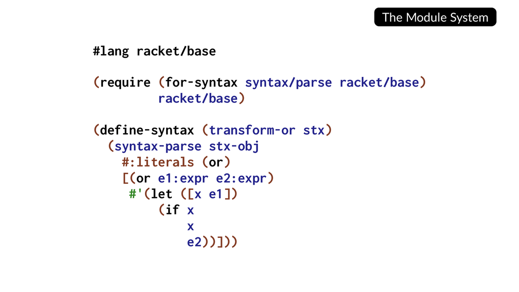

幻灯片 64：用 require 声明各阶段的依赖Slide 64: Declaring phase-specific dependencies with require

**幻灯片文字 / Slide text**

```
The Module System
#lang racket/base
(require
)
(define-syntax (transform-or stx)
  (
stx-obj
  #:literals (or)
  [(or e1:expr e2:expr)
#'(
([x e1])
  (
x
    x
    e2))]))
racket/base
if
let
(for-syntax syntax/parse racket/base)
syntax-parse
```

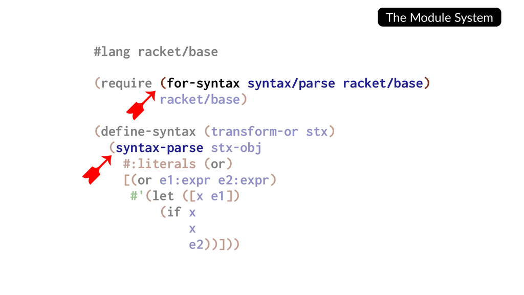

幻灯片 65：for-syntax 引入编译期所需的库Slide 65: for-syntax imports the libraries needed at compile time

**幻灯片文字 / Slide text**

```
The Module System
#lang racket/base
(require
)
(define-syntax (transform-or stx)
  (
stx-obj
  #:literals (or)
  [(or e1:expr e2:expr)
#'(
([x e1])
  (
x
    x
    e2))]))
racket/base
if
let
(for-syntax syntax/parse racket/base)
➹
syntax-parse
➹
```

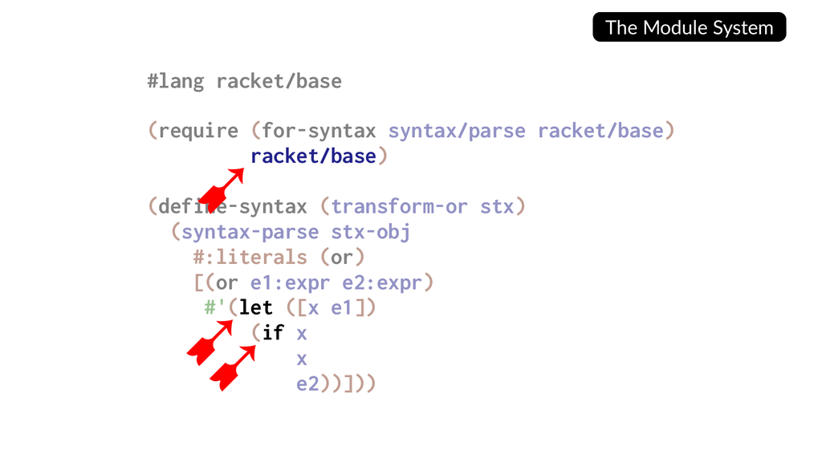

幻灯片 66：普通 require 引入运行期所需的基础形式Slide 66: An ordinary require imports the run-time basics

**幻灯片文字 / Slide text**

```
The Module System
#lang racket/base
(require
)
(define-syntax (transform-or stx)
  (
stx-obj
  #:literals (or)
  [(or e1:expr e2:expr)
#'(
([x e1])
  (
x
    x
    e2))]))
racket/base
➹
if
➹
let
➹
(for-syntax syntax/parse racket/base)
syntax-parse
```

所以，当你把这个东西的编译版本部署到云端之类的地方时，你的容器里并不需要放入那个库的实现。当然，这整个文件也可能通过另一个需要它的 for-syntax，被加载到别人的编译期。因此，这些数字是相对的，基本上相当于加一。好。

So the compiled version of this thing when you know deploy it to the cloud or whatever it's like that doesn't need to be in your in your container that the implementation of that library. Um and of course this entire file might be loaded at somebody else's compile time via some other force syntax that requires this one. So this might this is these are sort of relative numbers you know this is like plus one basically. Okay.

## Racket 隐藏的代码：微观剖析Racket's Hidden Code: A Microscopic Breakdown

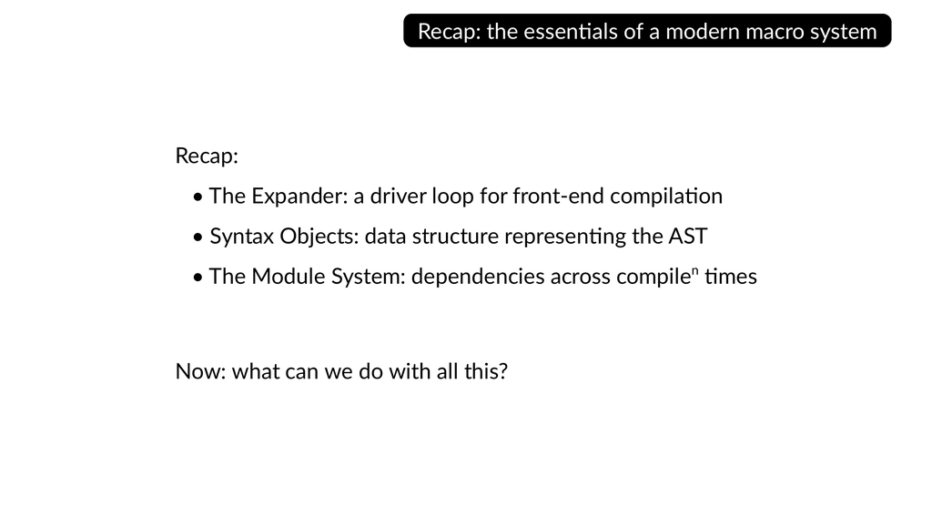

幻灯片 67：回顾：展开器、语法对象、模块系统Slide 67: Recap: the expander, syntax objects, and module system

**幻灯片文字 / Slide text**

```
Recap: the essentials of a modern macro system
Recap:
   • The Expander: a driver loop for front-end compilation
   • Syntax Objects: data structure representing the AST
   • The Module System: dependencies across compilen times
Now: what can we do with all this?
```

好，模块系统就是这样。我们回顾一下。我尝试解释的、构成现代宏系统基本骨架的三个部分是：有一个驱动循环，负责找出接下来该做什么；有一个数据结构，替我们管理作用域；还有模块系统，管理依赖，实际找到那些转换器。

Okay. That's module system. All right. So here's a recap. The three pieces I tried to explain that comprise the sort of basic bones of the modern macro system are we have this driver loop that sort of deals with finding the right thing to do next. We have the data structure that manages scope for us and the module system which manages the dependencies to actually find the transformers.

好，现在让我展示一下，利用所有这些东西，我们能做什么。我收到还剩十分钟的提示了，所以我可能要稍微加快一点。这个程序是错的。好，Racket 起源于教育。

Okay, so let me show you now what we can do with all this stuff. And I got the 10 minute I got the 10 minute thing. So okay, I might speed up a little. Um, this program's wrong. Okay, so the origins of racket are in education.

演示代码：初学者语言示例：函数调用中的括号Demo code: Beginner-language example: parentheses in function callsbsl.rkt

```
#lang racket

;; len : list-of-anything -> number
(define (len l)
  (cond
    [(empty? l) empty]
    [else (+ 1 len(rest l))]))
```

早在九十年代末，我们想教学生编程入门，却发现，正如我之前提到的，每一门专业编程语言对第一次编程的人来说都是一团乱麻，让人非常泄气。所以，这位学生非常认真地领会了课程内容，在 cond 里写上了方括号，也写了这里这种古怪的东西。但后来，哦，他们忘了，漏掉了一个。哎呀，真倒霉。

Back in the late 90s, we wanted to teach students introductory programming and discovered as I mentioned earlier, every professional programming language is just a big mess for first firsttime programmers and it's terribly dispiriting. So this student has very carefully internalized the lesson and put the square brackets in the con and they've put the weird this they did this weird thing here but then oh they forgot and they missed one. Oh dang it.

但是 Racket 会说：“好啊，没问题，我没有任何错误要报告给你。”因为它是为实际工作的程序员设计的。等你运行这段代码时，你会得到一条消息，说加法在对函数做加法之类的，然后你就会问：“你到底在说什么？”可是，如果把它放进初学者语言里——好，你可以把这个 #lang 基本上理解成第一个 require，以某种方式帮你启动整个过程。

So, but Racket's like, "Okay, cool. I can no problem. I have no errors for you, you know, if you because it's a it's designed for working programmers, you know, and you if you run this code, you're going to get some message about addition adding functions or something and you're going to be like, what are you talking about?" So, but if you put this in the beginning student language, okay, so you can think of this hashlang thing as basically like it's the first require somehow that sort of gets you started.

它找到第一个库，把你这门语言的基础功能引进来。现在，我们会得到一个编译期错误，说：“我期望在函数调用之前出现左括号。”初学者会说，好，这个我会改。你没有在跟我讲什么加号得到了一个函数——那到底是什么意思？那么，利用我到目前为止展示的工具，我们怎样做到这一点呢？

Find that first library to get the basics of your language in. Uh, now we get a compile time error and it says, I expected an open PN before a function call. Okay, I can fix that, said the beginning. Student, you're not talking about plus getting a function. What does that even mean? So, how do we get this using the tools that I've showed you so far in the talk?

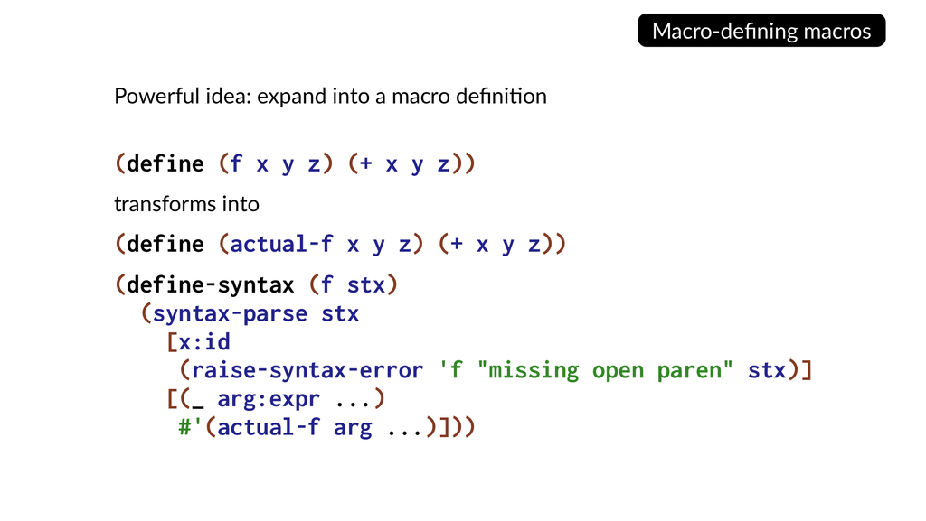

幻灯片 68：强大的思路：宏展开为另一个宏的定义Slide 68: Powerful idea: expand into a macro definition

**幻灯片文字 / Slide text**

```
Macro-defining macros
Powerful idea: expand into a macro definition
(define (f x y z) (+ x y z))
transforms into
(define (actual-f x y z) (+ x y z))
(define-syntax (f stx)
  (syntax-parse stx
  [x:id
(raise-syntax-error 'f "missing open paren" stx)]
  [(_ arg:expr ...)
#'(actual-f arg ...)]))
```

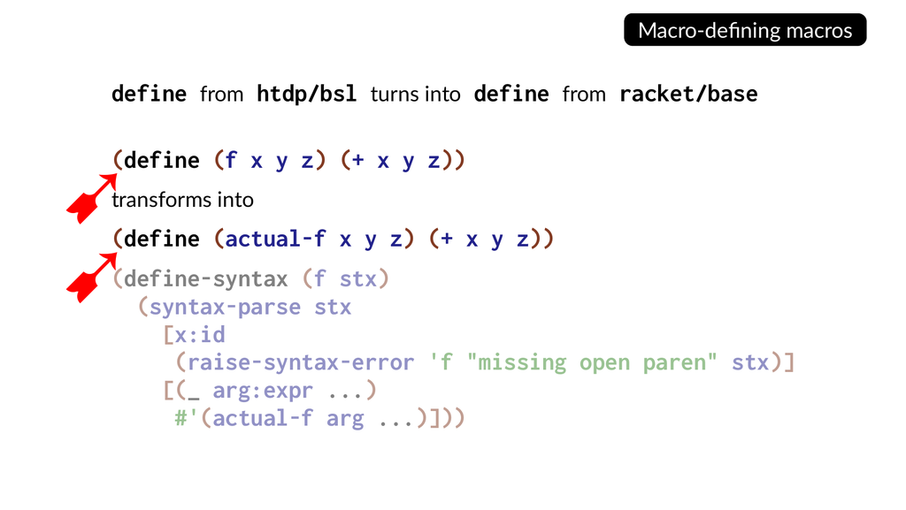

幻灯片 69：初学者语言的 define 转换为 racket/base 的 defineSlide 69: A define from htdp/bsl turns into a define from racket/base

**幻灯片文字 / Slide text**

```
Macro-defining macros
define from htdp/bsl turns into define from racket/base
(define
➹
(f x y z) (+ x y z))
transforms into
(define
➹
(actual-f x y z) (+ x y z))
(define-syntax (f stx)
  (syntax-parse stx
  [x:id
(raise-syntax-error 'f "missing open paren" stx)]
  [(_ arg:expr ...)
#'(actual-f arg ...)]))
```

好，那个强大的想法就是：编写一个宏，让它展开成另一个宏的定义。这听起来古怪又疯狂，但实际上没有那么复杂。这里有两个 define。这一个是 BSL，也就是初学者语言中的 define，而它将被编译成完整 Racket 编程语言中的 define。不过，我们在这里给它取名 actual-f。

Okay, so this is the powerful idea is that you write a macro that expands into a definition of a macro. That sounds weird and crazy, but it's actually not that it's not that complex. So here we have two defines. This is the define from the BSL, the beginning student language, and this is it's going to compile into a define for the full racket programming language. And but we give it the name actual f here.

因此，它当然会是绿色的。它相当于一个私有名称，因为它带着一个新作用域，这个作用域是加到这个宏的输出上的，其他人都没有。不过，看看我们对 f 做了什么：我们把定义里的 f 拿出来，放进了一个新宏的定义里。

So of course, this is going to be green. So it's like a private name because it has a new scope that nobody else has stuck on the output of this macro. So u but look what we did with the f. We took the f in the definition and put it into the definition of a new macro.

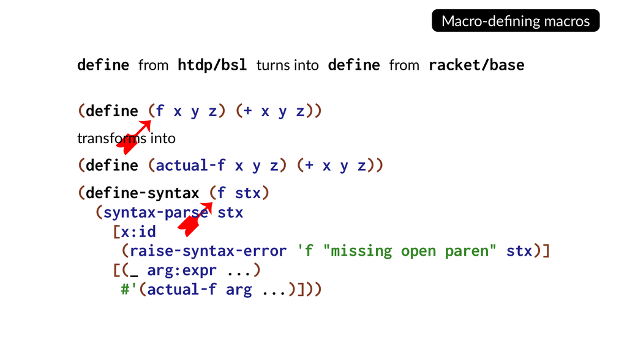

幻灯片 70：为函数名 f 建立一个宏Slide 70: Defining a macro for the function name f

**幻灯片文字 / Slide text**

```
Macro-defining macros
define from htdp/bsl turns into define from racket/base
(define (f
➹
x y z) (+ x y z))
transforms into
(define (actual-f x y z) (+ x y z))
(define-syntax (f
➹
stx)
  (syntax-parse stx
  [x:id
(raise-syntax-error 'f "missing open paren" stx)]
  [(_ arg:expr ...)
#'(actual-f arg ...)]))
```

所以，我们所做的，是利用程序中发生 define 的那个位置所具有的可见信息，让自己在编译期也能看到我们定义的函数在程序中被使用的那个位置。现在，学生只要写下 f，这个宏就会被调用。因此，我们可以使用 syntax-parse，给它两种情况。

So what we're doing is we're taking the visibility at the moment where define happened in the program and giving ourselves visibility into the moment where the function we're defining is being used at compile time in the program. So this macro now is going to be invoked whenever the student writes f. So we can now use syntax parse takes you know we give it two cases.

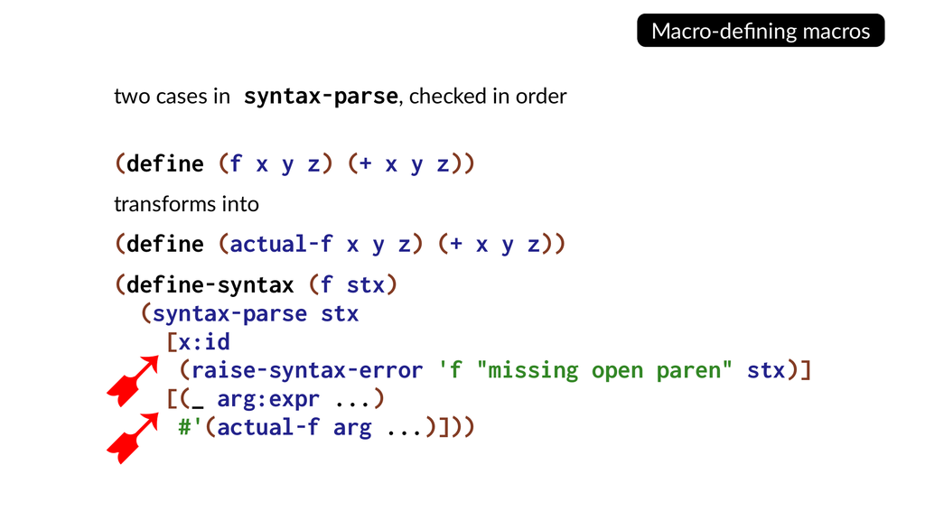

幻灯片 71：按顺序检查标识符和函数调用两种情况Slide 71: Checking the identifier and function-application cases in order

**幻灯片文字 / Slide text**

```
Macro-defining macros
two cases in syntax-parse, checked in order
(define (f x y z) (+ x y z))
transforms into
(define (actual-f x y z) (+ x y z))
(define-syntax (f stx)
  (syntax-parse stx
  [x:id
(raise-syntax-error 'f "missing open paren" stx)]
➹
  [(_ arg:expr ...)
#'(actual-f arg ...)]
➹
))
```

如果我们看到一个单独的标识符，就说明它没有出现在应用表达式的函数位置，因为它并不是紧跟在左括号后面的。那么，我们就直接调用 raise-syntax-error。

So if we see an identifier by itself that means it's not being used in the function position of an application expression because it's not being followed. It's not doesn't come immediately from a after an open pen. So we'll just call race syntax error.

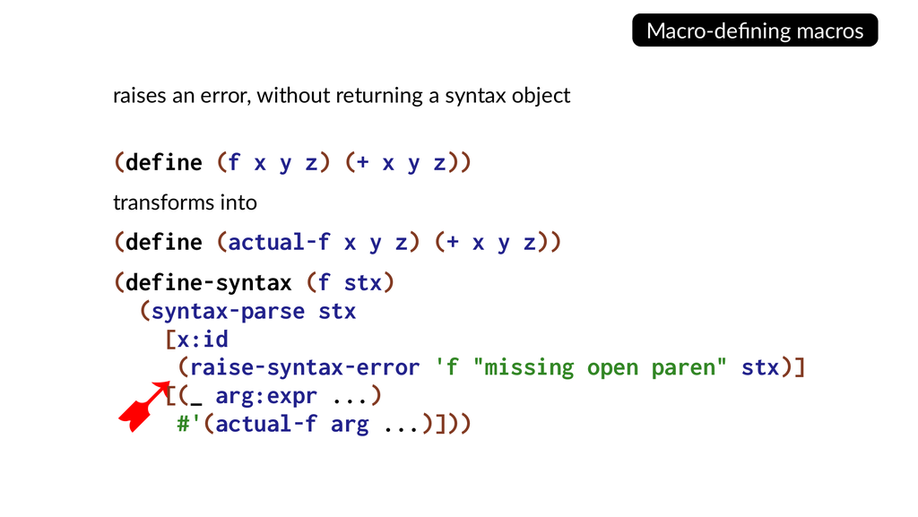

幻灯片 72：缺少左括号时直接报告语法错误Slide 72: Reporting a syntax error when an opening parenthesis is missing

**幻灯片文字 / Slide text**

```
Macro-defining macros
raises an error, without returning a syntax object
(define (f x y z) (+ x y z))
transforms into
(define (actual-f x y z) (+ x y z))
(define-syntax (f stx)
  (syntax-parse stx
  [x:id
(raise-syntax-error 'f "missing open paren" stx)
➹
]
  [(_ arg:expr ...)
#'(actual-f arg ...)]))
```

如果它确实出现在那个位置，我们就把 actual-f 替换进去，并且保留那些参数。raise-syntax-error 只是抛出一个异常，并不是什么特别的东西，每门编程语言都有类似机制。它构造一个——还剩五分钟——它构造一个数据结构，然后抛出异常。你看，它把这个 stx 传进去；stx 就是语法对象，其中包含源代码位置信息。DrRacket 就是这样能够把这里的东西高亮出来的。

If if it is then we'll substitute in actual f and just take the arguments raise syntax error just raises an exception you know it's not something special it's a thing every programming language has it builds a five minutes it builds a data structure and just throws the exception and you see what it puts this stx which is the syntax object which has the source location information in it and that's how Dr. racket was able to highlight this thing here.

## 在编程中报告错误：类型、宏与宏Signaling Errors in Programming: Types, Macros, and Macro

好，让我看看能不能……好，我们把这个想法再往前推进。我们想要……什么是最好的方法呢？编程语言研究界有足足百分之八十的人，都极其关心如何报告程序里的错误。他们把它叫作什么？类型。对，报告程序错误，简直是最棒的事情。我们就是要阻止人们干活。呜呼！好，对，对。

Okay, so let me let me see if I can't Okay, so let's take this idea even further. We'd like to what's the best way to you know the wellstied 80% of the PL research community cares very deeply about signaling errors in programs. And what do they call it? Types. Yeah, that's the best thing ever, signaling errors in programs. We want to stop people working. Woohoo. Okay. Yeah. Yeah.

演示代码：Typed Racket：带类型的单词计数函数Demo code: Typed Racket: a typed word-counting functiontr.rkt

```
#lang typed/racket

(: wc (-> Path-String Natural))
(define (wc fn)
  (call-with-input-file fn
    (λ ([port : Input-Port])
      (for/sum : Natural ([l (in-lines port)])
        (define words (regexp-split #px"\\s+" l))
        (length (remove* '("") words))))))
```

所以，我们也有一个这样的东西，因为它们确实很棒。好，刚才那番话我有一点开玩笑。不过，这里就是 Typed Racket，它真的是一个类型检查器。如果我删除这里对 length 的调用，它会告诉我类似这样的话：我期望一个非负整数，却得到了一个列表。

So, we got one of those, too, because we it's they're great. Okay, I'm being slightly facicious when I say that. But here, you know, so this is typed racket and it's really a type checker. You know, if I delete this call to length here, it's going to tell me something about, you know, I expected a non negative integer by a list.

去掉对 length 的调用后，你预期出的问题不就是这个吗？好。对，Natural 是非负整数的同义名称。所以，它获取了这里的类型声明，而这个东西返回一个列表。那么，好，它到底是怎样做到的呢？

Well, that's what you expect to go wrong when you take out a call to length, right? Okay. Um, yeah, natural is a natural is a synonym for non negative integer. So, it got the it got the type declaration here and then this thing returns a list. And so okay so how does how does this how does it do this?

如果你稍微想一下实际怎么实现，就会意识到——想想 or 宏，再想想实现这个类型检查器。你真的想为 or 制定一条新规则，为 and 制定一条新规则，为实际上也是宏的 cond 再制定一条新规则吗？这样会没完没了。

So if you think about actually implementing this for a moment you realize that like think about the or macro and think about implementing this. Do you want to come up with a new rule for or a new rule for and a new rule for cond is actually a macro a new rule it just goes on and on and on.

有各种各样的小宏，对它们来说，只要对展开后的东西应用类型规则，就完全够了。所以，Typed Racket 使用那个局部展开过程，然后对展开结果做类型检查。嘿，我还有六分钟。好，好，抱歉，好，好，好，好。天哪。

There's all these kind of little macros for which if you just wrote the use the typing rules on what they expand into you'd be fine. So that local expansion process typed bracket is using that and then type checking the thing it expands into. Hey I got six minutes. Okay. Okay. Sorry. Okay. Okay. Okay. Okay. Oh my god.

当然，并不是每一种构造都能这样处理。类系统展开后，会变成一个由方法函数组成的向量；你尽管试试给这种类系统的编译结果做类型检查，还要得到真正有意义的错误消息吧。所以，Typed Racket 还提供了更多一点的支持。

Um so of course not every construct you know the class system expands into like a vector of method functions and good luck trying to type check that the compilation of a class system and get actual meaningful error messages. So, type bracket has there's a little bit more support.

在决定是否执行递归展开的过程中，它能提供比我刚才展示的更多一点控制。不过，Typed Racket 利用了这个机制，省去了一些东西，获得软件工程上的好处，不必总是编写那么多类型规则。这里是 Redex。这是一门旨在帮助你避免在自己撰写的编程语言论文中犯错的编程语言。

It can control you have a little bit more control than I showed you in this recursive choose to do a recursive expansion process, but typed is using that facility to eliminate to for software engineering benefit and not having to write out so many type rules all the time. Um, here's Red X. This is a programming language designed to help you avoid errors in PL papers that you write.

## 为类型系统定义语言规则Defining Language Rules for Type Systems

演示代码：Redex：语言定义、类型判断与测试Demo code: Redex: language definitions, typing judgments, and testsredex.rkt

```
#lang racket
(require redex)

(define-language L

  (e ::= (e e) x (λ (x : τ) e))
  (τ ::= ι (-> τ τ))

  (Γ ::= · (+ x τ Γ))

  (x ::= variable-not-otherwise-mentioned))


(define-judgment-form L
  #:contract (⊢ Γ e τ)
  #:mode (⊢ I I O)

  [(⊢ Γ e_1 (-> τ_2 τ_3))   (⊢ Γ e_2 τ_2)
   --------------------------------------
   (⊢ Γ (e_1 e_2) τ_3)]

  [(⊢ (+ x τ_1 Γ) e τ_2)
   ----------------------------------
   (⊢ Γ (λ (x : τ_1) e) (-> τ_1 τ_2))]

  [(⊢ Γ x_1 τ_1)   (where #true (≠ x_1 x_2))
   -----------------------------------------
   (⊢ (+ x_2 τ_2 Γ) x_1 τ_1)]


  [-------------------------
   (⊢ (+ x_1 τ_1 Γ) x_1 τ_1)])

(define-metafunction L
  ≠ : x x -> boolean
  [(≠ x x) #false]
  [(≠ x_1 x_2) #true])


(test-judgment-holds (⊢ · (λ (x : ι) x) (-> ι ι)))
(test-judgment-holds (⊢ · (λ (y : ι) ((λ (x : ι) x) y)) (-> ι ι)))
(test-judgment-holds (⊢ · (λ (x : ι) (λ (f : (-> ι ι)) (f x))) (-> ι (-> (-> ι ι) ι))))
(test-judgment-holds (⊢ · (λ (x : ι) (λ (x : (-> ι ι)) x)) (-> ι (-> (-> ι ι) (-> ι ι)))))
(test-judgment-holds (⊢ · (λ (x : ι) (λ (y : (-> ι ι)) x)) (-> ι (-> (-> ι ι) ι))))

(with-compound-rewriters
    (['⊢ (λ (lws) (list (list-ref lws 2) " ⊢ " (list-ref lws 3) " : " (list-ref lws 4)))]
     ['≠ (λ (lws) (list (list-ref lws 2) "≠" (list-ref lws 3)))]
     ['-> (λ (lws) (list "" (list-ref lws 2) " → " (list-ref lws 3)))]
     ['+ (λ (lws) (list "{" (list-ref lws 2) ":" (list-ref lws 3) "} ⊕ " (list-ref lws 4)))])
  (render-judgment-form ⊢))

(generate-term L #:satisfying (⊢ · e τ) 3)
```

你的做法是，定义一门语言，也就是你正在研究的对象。这里有 e、τ 以及其他一些东西。然后你可以给它提供语义、类型系统等等，可以对这门语言做各种语法层面的事情。比如，这里就是应用表达式的类型规则。

Um, so what you do is you define a language that's the thing you're studying. So here we've got it's got you know e and toao and some stuff and then you can you can you can give the you can give a semantics or type system or whatever you can do syntactic things with your with your language. So like here's the rule for typing applications.

说到宏，Redex 所做的，是把 define-language 转换成 define-syntax L。不过，它并不是把 L 绑定到转换器，而是把 L 绑定到关于这门语言的一大包信息。例如，如果我把这里的 e 改成另一个 E，再运行这个程序，它就会说：“嘿，你写了一个下划线，而它前面的东西并不是非终结符。”

Um so coming to macros what racket what redex is doing is it's taking defined language and turning it into defined syntax l but it's not binding l to a transformer it's binding l to just a pile of information about what's in the language. So, for example, if I change this E into like E and I run this program, it says, hey, you wrote an underscore before something that's not a non terminal.

它之所以知道，是因为 L 带着那一包信息，其中就包括非终结符的名字等等。所以，这就是为什么那个环境把标识符映射到你想映射的任意东西。

And how it knew that was because L had that packet of information and including among other things what the names of the non terminals are. Okay, so that's one of the that's the reason why that environment just maps identifiers to whatever you want to map them to.

你可以用 define-syntax，不一定是定义宏转换器，也可以只是把有用的信息放进环境里，之后通过其他宏把它查出来。信息就是这样从这个 L 传到下面这个 L 的。而对程序员来说，这种思维方式完全自然，对吧？“哦，对，我定义了一门语言 L，现在我正在语言 L 中写这个判断。”

And you can use define syntax to not necessarily define a macro transformer, but just to put useful information into the environment which you can then look up with through other macros. So that's how this information is communicated from this L down to this L. And a totally natural way, right, for the programmer to think, oh yeah, of course you I defined a language L. Now I'm writing this judgment in the language L.

因此，在那里写两次 L 是合理的，宏就借助了这一点。把作用域用作通信机制，是一件非常常见、也非常顺手的事情，宏系统对此提供了支持。遗憾的是，我实在没有时间向大家解释 Turnstile 是怎样工作的。不过，我只是想指出，它非常厉害。好，看看这个 define-typed-syntax。

So it makes sense to put L there twice. And the macro piggybacks on that. The scope is using scope as a communication mechanism is very common and comfortable thing to do that the macro system is supporting this. Uh this I really can't explain how turn style works to you unfortunately. Um but I just want to point out how awesome it is. All right. So check out this define typed syntax.

演示代码：Turnstile：可组合的双向类型规则Demo code: Turnstile: composable bidirectional typing rulesturnstile.rkt

```
#lang turnstile/quicklang

(provide → λ #%app ann Int)
(define-base-type Int)
(define-type-constructor → #:arity >= 1)

(define-typed-syntax λ #:datum-literals (:)
  [(_ ([x:id : τ_in:type] ...) e) ≫
   [[x ≫ x- : τ_in.norm] ... ⊢ e ≫ e- ⇒ τ_out]
   -------
   [⊢ (#%plain-lambda (x- ...) e-) ⇒ (→ τ_in.norm ... τ_out)]]
  [(_ (x:id ...) e) ⇐ (~→ τ_in ... τ_out) ≫
   [[x ≫ x- : τ_in] ... ⊢ e ≫ e- ⇐ τ_out]
   ---------
   [⊢ (#%plain-lambda (x- ...) e-)]])

(define-typed-syntax (#%app e_fn e_arg ...) ≫
  [⊢ e_fn ≫ e_fn- ⇒ (~→ τ_in ... τ_out)]
  #:fail-unless (stx-length=? #'[τ_in ...] #'[e_arg ...])
                (num-args-fail-msg #'e_fn #'[τ_in ...] #'[e_arg ...])
  [⊢ e_arg ≫ e_arg- ⇐ τ_in] ...
  --------
  [⊢ (#%plain-app e_fn- e_arg- ...) ⇒ τ_out])

(define-typed-syntax (ann e (~datum :) τ:type) ≫
  [⊢ e ≫ e- ⇐ τ.norm]
  --------
  [⊢ e- ⇒ τ.norm])
```

它类似 define-syntax，采用开放式编译器的这个想法：我们可以混合搭配不同分支，做各种事情。但它不是把这个想法用于编译器前端，而是用于类型系统。关于它，我大概只能说这么多。这些都是独立的规则。它必须是一个双向类型系统，因为这些规则里必须以某种方式包含算法。

So, it's like define syntax and it's taking this idea of the open compiler and we're going to mix and match cases and do whatever, but it's doing it for the type system instead of the front end compiler. So, that's maybe all I can say about it. But these are individual rules. It has to be a birectional type system because that's like an algorithm somehow in in those rules.

不过，如果像这样编写，你写下的类型规则就能够混合搭配，想选哪些就选哪些。这与你利用宏来实现开放前端时，能够混合搭配编译器中的各个分支，是同样的道理。好。

But if you write them like this, you're writing down type rules that you can mix and match and pick up whatever you want, which ones you want. In the same way you can mix and match cases in the compiler when you're you know using macros to do an open front end. All right.

## 把函数的名字改成 XChanging the name of the function to X

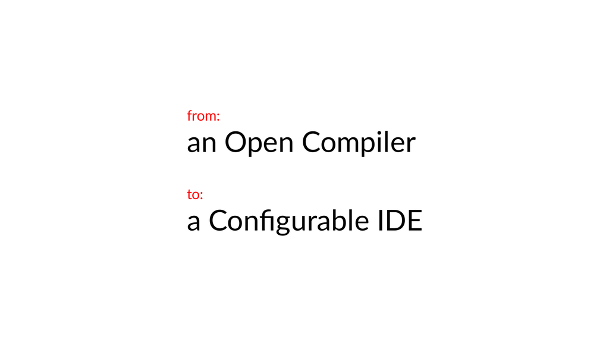

幻灯片 73：从开放式编译器走向可配置的 IDESlide 73: From an Open Compiler to a Configurable IDE

**幻灯片文字 / Slide text**

```
from:
an Open Compiler
to:
a Configurable IDE
```

最后我想说的是，未来五年左右，我们希望沿着什么方向发展：利用这些开放式编译器的想法，为 IDE 提供支持。我们已经有了一些这方面的支持。比如，你们已经看到这里有一些漂浮的线之类的东西。我在这里展示一下。

Um the last thing I want to say is the where we're hope to go in the like the next five years or so with this is to be able to take these ideas about an open compiler and turn leverage them to get IDE support. And we have some support for this already. So like you've seen these things kind of like these lines floating around here. I'll show you here.

你们已经看到这些绿色的东西、这些箭头等等。如果我们修正这个程序，也会看到其中的一些错误。那么，这里的这些箭头和这里的那些箭头，都是由同一套代码产生的。

So you've seen these like green stuff and these arrows and whatever. Um, so those if I if we fix this program, we're going to get some errors in it, too. So, these arrows here in this and the arrows in here are coming from the same pile of code.

它们都是先把程序完全展开，再利用那个作用域集合机制，确定在完全展开的程序中，哪些标识符是绑定者，哪些是相应的引用出现位置。然后取得它们的源代码位置，把这些位置和连接关系交给 GUI。接下来由 GUI 接手，当你把鼠标移到上面时，它会作出响应，也允许你重命名。这在这两门语言中都完全是自动工作的。

They're both just fully expanding the program and then using that set of scopes, you know, thing to determine which things are which identifiers are binders and which ones are occurrences of you know, in in that fully expanded program, getting the source locations of them and then giving it to the GUI in terms of source locations and connections and then the GUI just takes it from there and when you mouse over it and stuff and it lets you rename things and that works completely automatically in these two languages.

在 Redex 中，发生了一些挺疯狂的事情：它们以某种方式从 L 经过下面这个 L，再到这个 e，最后找到了它。而下面这里其实更复杂。比如看这个 e_1，我没有解释原因，但它实际上是这个 e1 的绑定出现位置。这里有一个函数，它在内部生成了一个函数，诸如此类。

In Red X, you know, there's like some crazy stuff happening with like they're somehow going they're somehow going through L down into this L into this E is how it's finding it somehow. And it's actually kind of worse down here. Like if you look at this E_1, this is actually I didn't get into why, but this is a binding occurrence for this E1. Like there's a function. It's generating a function internally and whatever.

好，不过，e 这一部分也与上面那个有关，因为你也许并不想用 e 这个名字，而想叫它 x，因此希望把它们全都重命名为 x。DrRacket 无法在这里自动弄清这些关系。不过，Redex 的程序员——他可能与 DrRacket 的程序员有点关系——额外写了少量代码，让它能够工作。

Okay, but the but the E part is al is also one up here because maybe E is not the name you wanted. you wanted to call it X and so you want to rename them all to X. Um so Dr. Racket cannot automatically figure them out here but there's just a little bit of extra code that the Redex programmer who may be related to the Dr. Racket programmer wrote to be able to get this to work.

好，现在想想这个：如果我们能把这种方法用于某种分析，那么就能拥有由这种分析支撑的重构工具，而这种分析在大多数情况下，都能自行计算出它需要计算的东西。

Okay, so think of that now. What if we could do this for an analysis and then we could have refactoring tools that are backed by this analysis that for the most part just calculates what it needs to calculate on its own.

但你也许还可以做一些与 define-typed-syntax 思路相同的事情，在宏里提供一点信息：“哦，对，不要尝试分析展开后的形式，那样太疯狂了。这一个稍微复杂一点，下面是你针对它所需要的规则。”

But you could maybe do something sort of in the same spirit of defined type syntax where you give a as part of your macro a little bit of information about oh yeah don't don't try to do your analysis on the expanded form. That's crazy. Here's the rule that you need for this one because this one's a little bit more complicated.

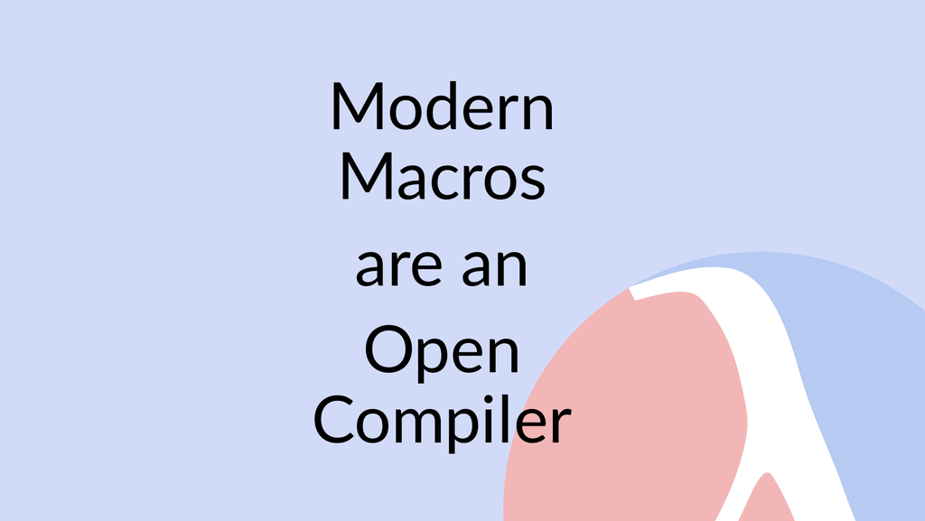

幻灯片 74：再次回到核心论点：现代宏是开放式编译器Slide 74: Returning to the thesis: Modern Macros are an Open Compiler

**幻灯片文字 / Slide text**

```
Modern
Macros
are an
Open
Compiler
```

然后，我们就能利用这些信息，以相对较少的投入，为所有这些不同的编程语言提供真正出色的 IDE 支持。好，这就是我们接下来想去的方向。耶！好。那么，这就是核心论点。我想，这组词未必最适合描述你们在过去一小时里看到的内容，不过，希望它能成为一句让你们记住的口号。

And then we could leverage that and and get, you know, really h really awesome IDE support for all these different programming languages with relatively little effort. Okay, that's where Okay, that's where we try to go next. Yay. All right. Okay, so here's the thesis. I would say this is not the best collection of words to necessarily maybe describe what you've seen in this last hour, but okay. Hopefully it's a slogan that'll stick with you.

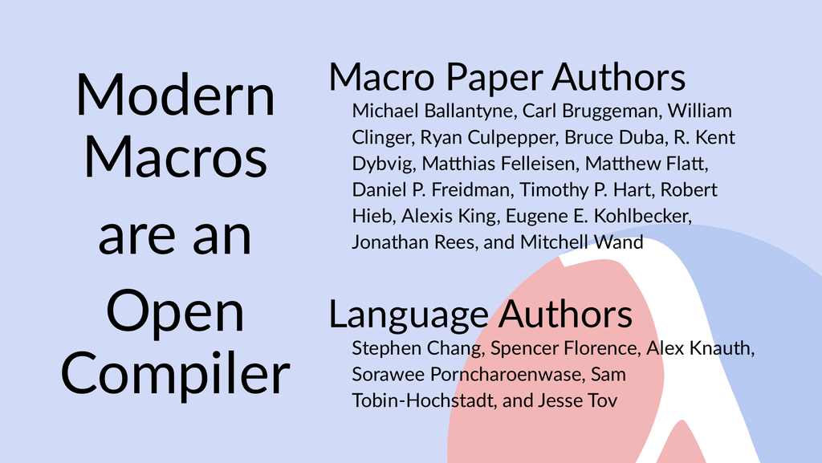

幻灯片 75：致谢：宏论文作者与语言作者Slide 75: Acknowledgments: macro paper authors and language authors

**幻灯片文字 / Slide text**

```
Modern
Macros
are an
Open
Compiler
Macro Paper Authors
Michael Ballantyne, Carl Bruggeman, William
Clinger, Ryan Culpepper, Bruce Duba, R. Kent
Dybvig, Matthias Felleisen, Matthew Flatt,
Daniel P. Freidman, Timothy P. Hart, Robert
Hieb, Alexis King, Eugene E. Kohlbecker,
Jonathan Rees, and Mitchell Wand
Language Authors
Stephen Chang, Spencer Florence, Alex Knauth,
, Sam
Tobin-Hochstadt, and Jesse Tov
Sorawee Porncharoenwase
```

如果你有更好的说法，请告诉我。最后让我列一下致谢名单。这些人是前面那些论文的作者，也包括随后一些论文的作者。在我看来，那些都是特别重要的论文，他们也是现代宏背后基础工作的特别重要的贡献者。而这些人编写了我刚才展示的那些语言。我还想特别提一下 Sorawee Porncharoenwase。

If you have a better version of it, tell me. And then let me just roll some credits here. Um these are these people are authors of those papers and then some papers that came after them that are particularly important papers in my opinion particularly important contributors to the background behind modern macros. And these are the people who wrote the languages that I that I showed you. And I just want to call out Sorowi.

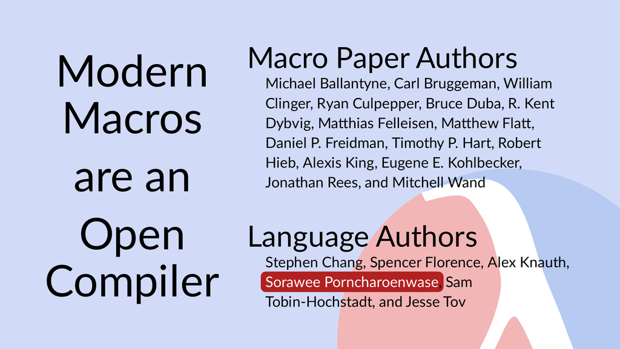

幻灯片 76：特别介绍 Sorawee PorncharoenwaseSlide 76: Highlighting Sorawee Porncharoenwase

**幻灯片文字 / Slide text**

```
Modern
Macros
are an
Open
Compiler
Macro Paper Authors
Michael Ballantyne, Carl Bruggeman, William
Clinger, Ryan Culpepper, Bruce Duba, R. Kent
Dybvig, Matthias Felleisen, Matthew Flatt,
Daniel P. Freidman, Timothy P. Hart, Robert
Hieb, Alexis King, Eugene E. Kohlbecker,
Jonathan Rees, and Mitchell Wand
Language Authors
Stephen Chang, Spencer Florence, Alex Knauth,
, Sam
Tobin-Hochstadt, and Jesse Tov
Sorawee Porncharoenwase
```

他是华盛顿大学的一名博士生，导师是 Emina Torlak，今年即将毕业，正在求职。他在能够从事的工作方面有一些限制，不过，如果你觉得这些东西很有意思，而且认为你所在的机构也许有适合这类工作的职位，我鼓励你联系他，或者我也很乐意帮你们介绍。谢谢，非常感谢。

He's a PhD student at University of Washington whose advisor is Amina Torlac and he's graduating this year. and on the market. So, he has some constraints in what he can do, but if this stuff seems interesting to you then, and you think maybe you have a place for this sort of thing at your institution, then I encourage you to reach out or I'll be happy to introduce you to it. Thank you. Thank you very much.

## 可互操作语言中的互操作性挑战Interoperability Challenges in Interoperable Languages

Host

很遗憾，时间已经到了，不过也许还能问一个问题。报告过程中我们已经问了很多问题。那么，你有……

Unfortunately, run out of time, but maybe there is one question. So, we had already a lot of question during the talks. So, you have

Robby Findler

有人问，如果我要完全从零开始，在一片空白上编写自己的编程语言，是不是应该用这种方式？对。好，是的。我的意思是，当然总有改进的空间。

Somebody asked question if I was writing my own programming language from full scratch totally green field would I should I do it this way? Yeah. Okay. Yeah, I mean there's always there's always room for improvement.

完全如此。所以我想，不过，我肯定会利用我们已经掌握的、关于如何组织宏系统的知识，把它应用到你从零开始构建的新语言中。这会是一个不错的选择。对，对。

Totally and so I think that but I would definitely taking advantage of what's known about how to structure macro systems and putting that into your new green field language is that would be a good move. Yeah. Yeah.

Audience

好，也许我问一个问题：对于其他语言，如果你不想使用括号，比如那个 Python 的例子，你会怎样处理？

Robby Findler

对，是的。遗憾的是，Racket 对解析器没有提供太多东西。不过，像 Rascal 或者 ADF、SDF，那些人有非常出色的解析器组合工具，最好去看看他们的东西。但从 Racket 的角度来说，你需要编写一个解析器，把字节序列转换成初始的语法对象，其中所有位置上的作用域集合都是空的，然后从那里开始用宏继续处理。

yeah so yeah so I racket dumb does not have a lot to say about parsers unfortunately but like rascal or ADF SDF those people have sort of fantastic sort of parser combination composition tools that you that those are the best things to look into But from the racket point of view, what you do is you write the parser that takes your bytes and gives you that initial syntax object where the set of scopes are all empty everywhere and then you take it from there with the macros.

Audience

也就是说，没有直接的支持。

There was no direct support.

Robby Findler

对，不过，我们也有类似 Bison 的实现之类的东西。所以，就是这样。

Yeah, but you know we've got like you know a bison clone or something. So okay.

Host

那么，还有一个问题，如果我们再来一个。好，我不知道我们是不是……好，抱歉。对，好。

So there's one more if we one more. Okay. I don't know if we one. Okay. I'm sorry. Yeah. Okay.

Audience

用这种方式定义的语言，在多大程度上可以……比如你展示了几种不同的语言，它们基本上是完全不同的语言，但都建立在这个系统上。

Uh to what extent can languages defined this way like you showed several different languages that are basically completely different languages that are built on top of this system.

它们在多大程度上可以相互操作？比如，可以从一种语言中导入另一种语言吗？

To what extent can they like interoperate with each other? Like can you import one from another?

Robby Findler

可以。不过，如果语义……你知道，它们都编译到一门共同的语言，所以你可以把它们一起导入。但如果这些编译器各自依赖的不变量彼此不兼容，就可能发生奇怪的事情。如何实现互操作性，在这里是一个非常大的问题。

Yes. And it will do something weird if the semantics you know because they're compiling into a common language and so you can you can import them together and something weird might happen if the invariants of the compilers you know don't respect each other. There's a very big problem there of how to how to do interoperability.

Audience

那么，真的有人成功利用这一点，构建过有意思而且有用的程序吗？

Well, have people ever actually manage to use this to build an interesting and useful program.

Robby Findler

你有，你有，我……我这么说吧：Racket 本身没有为确保这种组合正常工作提供任何直接支持。不过，在研究界，我们有一些相关的理论框架。可以看看 Amal Ahmed 的工作，这是思考如何做这类事情的一个很好的起点。

You have you have I let's I'll say this that racket itself does not offer any direct support for making that work. Well, there's some intellectual frameworks that are that we have in the research community. Check out Amal Ahmed's work is a good starting point for how to think about how to do this kind of thing.

不过，从我们这里的角度看，就是你有两个编译器，都编译到同一门语言。把它们组合起来，可能发生奇怪的事情，但也可能效果很好。对，好，再次感谢。谢谢。

Um but it's you know from here from this point of view it's like you've got two compilers that compile into the same language. Put them together you know it might do something weird but it might be great. Yeah. Okay. Thanks again for Thank you.

使用 https://www.appblit.com/quickscribe 转录

Transcribed with https://www.appblit.com/quickscribe